# collegiateSports

Braden Buchanan

2023-09-08

# load packages

```r
library(tidyverse)
library(stringr)
library(forcats)
library(scales)
```

# Load data

```r
sports <- readr::read_csv('https://raw.githubusercontent.com/rfordatascience/tidytuesday/master/data/2022/2022-03-29/sports.csv')
```

### Check out data

```r
colnames(sports)
```

```
##  [1] "year"                 "unitid"               "institution_name"
##  [4] "city_txt"             "state_cd"             "zip_text"
##  [7] "classification_code"  "classification_name"  "classification_other"
## [10] "ef_male_count"        "ef_female_count"      "ef_total_count"
## [13] "sector_cd"            "sector_name"          "sportscode"
## [16] "partic_men"           "partic_women"         "partic_coed_men"
## [19] "partic_coed_women"    "sum_partic_men"       "sum_partic_women"
## [22] "rev_men"              "rev_women"            "total_rev_menwomen"
## [25] "exp_men"              "exp_women"            "total_exp_menwomen"
## [28] "sports"
```

```r
str(sports)
```

```
## spc_tbl_ [132,327 × 28] (S3: spec_tbl_df/tbl_df/tbl/data.frame)
##  $ year                : num [1:132327] 2015 2015 2015 2015 2015 ...
##  $ unitid              : num [1:132327] 100654 100654 100654 100654 100654 ...
##  $ institution_name    : chr [1:132327] "Alabama A & M University" "Alabama A & M University" "Alabama A & M University" "Alabama A & M University" ...
##  $ city_txt            : chr [1:132327] "Normal" "Normal" "Normal" "Normal" ...
##  $ state_cd            : chr [1:132327] "AL" "AL" "AL" "AL" ...
##  $ zip_text            : chr [1:132327] "35762" "35762" "35762" "35762" ...
##  $ classification_code : num [1:132327] 2 2 2 2 2 2 2 2 2 2 ...
##  $ classification_name : chr [1:132327] "NCAA Division I-FCS" "NCAA Division I-FCS" "NCAA Division I-FCS" "NCAA Division I-FCS" ...
##  $ classification_other: chr [1:132327] NA NA NA NA ...
##  $ ef_male_count       : num [1:132327] 1923 1923 1923 1923 1923 ...
##  $ ef_female_count     : num [1:132327] 2300 2300 2300 2300 2300 2300 2300 2300 2300 2300 ...
##  $ ef_total_count      : num [1:132327] 4223 4223 4223 4223 4223 ...
##  $ sector_cd           : num [1:132327] 1 1 1 1 1 1 1 1 1 1 ...
##  $ sector_name         : chr [1:132327] "Public, 4-year or above" "Public, 4-year or above" "Public, 4-year or above" "Public, 4-year or above" ...
##  $ sportscode          : num [1:132327] 1 2 3 7 8 15 16 22 26 33 ...
##  $ partic_men          : num [1:132327] 31 19 61 99 9 NA NA 7 NA NA ...
##  $ partic_women        : num [1:132327] NA 16 46 NA NA 21 25 10 16 9 ...
##  $ partic_coed_men     : num [1:132327] NA NA NA NA NA NA NA NA NA NA ...
##  $ partic_coed_women   : num [1:132327] NA NA NA NA NA NA NA NA NA NA ...
##  $ sum_partic_men      : num [1:132327] 31 19 61 99 9 0 0 7 0 0 ...
##  $ sum_partic_women    : num [1:132327] 0 16 46 0 0 21 25 10 16 9 ...
##  $ rev_men             : num [1:132327] 345592 1211095 183333 2808949 78270 ...
##  $ rev_women           : num [1:132327] NA 748833 315574 NA NA ...
##  $ total_rev_menwomen  : num [1:132327] 345592 1959928 498907 2808949 78270 ...
##  $ exp_men             : num [1:132327] 397818 817868 246949 3059353 83913 ...
##  $ exp_women           : num [1:132327] NA 742460 251184 NA NA ...
##  $ total_exp_menwomen  : num [1:132327] 397818 1560328 498133 3059353 83913 ...
##  $ sports              : chr [1:132327] "Baseball" "Basketball" "All Track Combined" "Football" ...
##  - attr(*, "spec")=
##   .. cols(
##   ..   year = col_double(),
##   ..   unitid = col_double(),
##   ..   institution_name = col_character(),
##   ..   city_txt = col_character(),
##   ..   state_cd = col_character(),
##   ..   zip_text = col_character(),
##   ..   classification_code = col_double(),
##   ..   classification_name = col_character(),
##   ..   classification_other = col_character(),
##   ..   ef_male_count = col_double(),
##   ..   ef_female_count = col_double(),
##   ..   ef_total_count = col_double(),
##   ..   sector_cd = col_double(),
##   ..   sector_name = col_character(),
##   ..   sportscode = col_double(),
##   ..   partic_men = col_double(),
##   ..   partic_women = col_double(),
##   ..   partic_coed_men = col_double(),
##   ..   partic_coed_women = col_double(),
##   ..   sum_partic_men = col_double(),
##   ..   sum_partic_women = col_double(),
##   ..   rev_men = col_double(),
##   ..   rev_women = col_double(),
##   ..   total_rev_menwomen = col_double(),
##   ..   exp_men = col_double(),
##   ..   exp_women = col_double(),
##   ..   total_exp_menwomen = col_double(),
##   ..   sports = col_character()
##   .. )
##  - attr(*, "problems")=<externalptr>
```

```r
summary(sports)
```

```
##       year          unitid       institution_name     city_txt
##  Min.   :2015   Min.   :100654   Length:132327      Length:132327
##  1st Qu.:2016   1st Qu.:149781   Class :character   Class :character
##  Median :2018   Median :181738   Mode  :character   Mode  :character
##  Mean   :2018   Mean   :184360
##  3rd Qu.:2019   3rd Qu.:214069
##  Max.   :2019   Max.   :800001
##
##    state_cd           zip_text         classification_code classification_name
##  Length:132327      Length:132327      Min.   : 1.000      Length:132327
##  Class :character   Class :character   1st Qu.: 4.000      Class :character
##  Mode  :character   Mode  :character   Median : 6.000      Mode  :character
##                                        Mean   : 7.779
##                                        3rd Qu.:12.000
##                                        Max.   :20.000
##
##  classification_other ef_male_count   ef_female_count ef_total_count
##  Length:132327        Min.   :    0   Min.   :    0   Min.   :    0
##  Class :character     1st Qu.:  513   1st Qu.:  652   1st Qu.: 1194
##  Mode  :character     Median :  986   Median : 1248   Median : 2259
##                       Mean   : 2126   Mean   : 2496   Mean   : 4622
##                       3rd Qu.: 2385   3rd Qu.: 2860   3rd Qu.: 5237
##                       Max.   :35954   Max.   :30325   Max.   :66279
##
##    sector_cd     sector_name          sportscode      partic_men
##  Min.   : 1.00   Length:132327      Min.   : 1.00   Min.   :  1.00
##  1st Qu.: 1.00   Class :character   1st Qu.: 7.00   1st Qu.: 13.00
##  Median : 2.00   Mode  :character   Median :16.00   Median : 22.00
##  Mean   : 2.21                      Mean   :16.34   Mean   : 30.86
##  3rd Qu.: 2.00                      3rd Qu.:25.00   3rd Qu.: 35.00
##  Max.   :99.00                      Max.   :38.00   Max.   :331.00
##                                                     NA's   :70462
##   partic_women    partic_coed_men  partic_coed_women sum_partic_men
##  Min.   :  1.00   Min.   :  1.00   Min.   : 1.00     Min.   :  0.00
##  1st Qu.: 11.00   1st Qu.:  4.00   1st Qu.: 5.00     1st Qu.:  0.00
##  Median : 16.00   Median :  8.00   Median :10.00     Median :  0.00
##  Mean   : 20.71   Mean   : 11.05   Mean   :14.17     Mean   : 14.49
##  3rd Qu.: 23.00   3rd Qu.: 14.00   3rd Qu.:19.00     3rd Qu.: 20.00
##  Max.   :327.00   Max.   :130.00   Max.   :91.00     Max.   :331.00
##  NA's   :63442    NA's   :131560   NA's   :131560
##  sum_partic_women    rev_men            rev_women        total_rev_menwomen
##  Min.   :  0.00   Min.   :       65   Min.   :       0   Min.   :      130
##  1st Qu.:  0.00   1st Qu.:    63428   1st Qu.:   58746   1st Qu.:    96299
##  Median :  6.00   Median :   158126   Median :  138318   Median :   228776
##  Mean   : 10.86   Mean   :   809011   Mean   :  279346   Mean   :   795231
##  3rd Qu.: 17.00   3rd Qu.:   400604   3rd Qu.:  331120   3rd Qu.:   541876
##  Max.   :327.00   Max.   :156147208   Max.   :21440365   Max.   :156147208
##                   NA's   :70462       NA's   :63444      NA's   :45193
##     exp_men           exp_women       total_exp_menwomen    sports
##  Min.   :      65   Min.   :     65   Min.   :     130   Length:132327
##  1st Qu.:   63062   1st Qu.:  59301   1st Qu.:   96436   Class :character
##  Median :  159666   Median : 141800   Median :  234559   Mode  :character
##  Mean   :  662386   Mean   : 331594   Mean   :  732422
##  3rd Qu.:  424025   3rd Qu.: 361860   3rd Qu.:  585604
##  Max.   :69718059   Max.   :9485162   Max.   :69718059
##  NA's   :70462      NA's   :63442     NA's   :45191
```

# Descriptive Statistics

### What schools generate the most revenue?

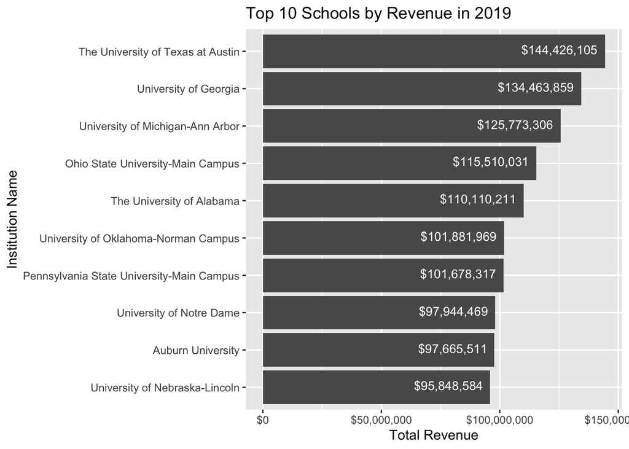

```r
highestRevSchools2019 <- sports %>%
  select(year, institution_name, state_cd, total_rev_menwomen, sports) %>%
  filter(year == 2019) %>%
  arrange(desc(total_rev_menwomen)) %>%
  head(n = 10)

ggplot(highestRevSchools2019, aes(x = total_rev_menwomen, y = fct_reorder(institution_name, total_rev_menwomen))) +
  geom_bar(stat = "identity") +
  geom_text(aes(label = scales::dollar(total_rev_menwomen)), vjust = .3, hjust = 1.1, color = "white", size = 3.5) +
  scale_x_continuous(labels = scales::dollar_format(scale = 1)) +
  labs(title = "Top 10 Schools by Revenue in 2019",
       x = "Total Revenue",
       y = "Institution Name")
```

### What schools generate the least revenue?

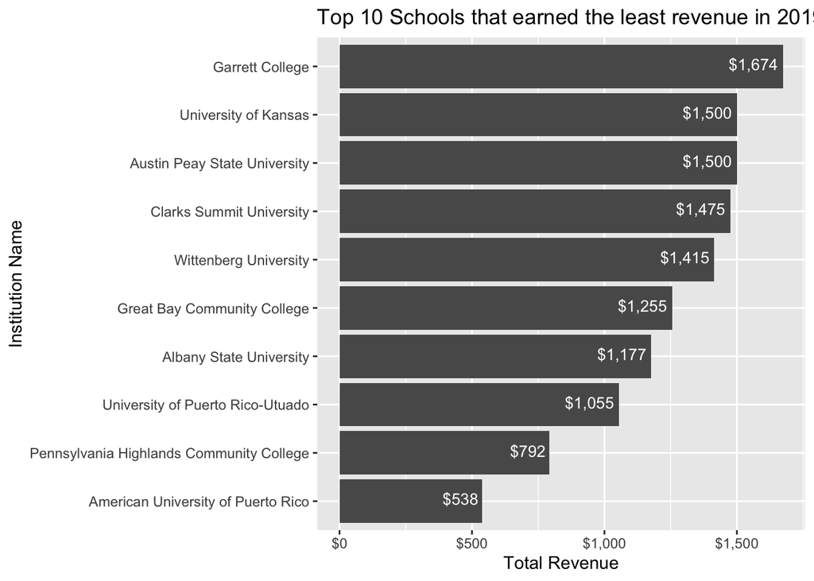

```r
lowestRevSchools2019 <- sports %>%
  select(year, institution_name, state_cd, total_rev_menwomen, sports) %>%
  filter(year == 2019) %>%
  arrange(total_rev_menwomen) %>%
  distinct(institution_name, .keep_all = TRUE) %>%
  head(n=10)

ggplot(lowestRevSchools2019, aes(x = total_rev_menwomen, y = fct_reorder(institution_name, total_rev_menwomen))) +
  geom_bar(stat = "identity") +
  geom_text(aes(label = scales::dollar(total_rev_menwomen)), vjust = .3, hjust = 1.1, color = "white", size = 3.5) +
  scale_x_continuous(labels = scales::dollar_format(scale = 1)) +
  labs(title = "Top 10 Schools that earned the least revenue in 2019",
       x = "Total Revenue",
       y = "Institution Name")
```

### What sports programs generate the most revenue for their schools?

```r
sports %>%
  group_by(sports) %>%
  summarise(total_revenue = sum(total_rev_menwomen, na.rm = TRUE)) %>%
  arrange(desc(total_revenue)) %>%
  head(10)
```

```
## # A tibble: 10 × 2
##    sports             total_revenue
##    <chr>                      <dbl>
##  1 Football             27656662780
##  2 Basketball           15080044942
##  3 Soccer                4437216001
##  4 Baseball              3491245241
##  5 All Track Combined    2859152770
##  6 Volleyball            2657342705
##  7 Softball              2308131793
##  8 Tennis                1647758263
##  9 Golf                  1646888264
## 10 Lacrosse              1518166788
```

```r
top_schools <- sports %>%
  group_by(institution_name) %>%
  summarise(school_total_revenue = sum(total_rev_menwomen, na.rm = TRUE)) %>%
  arrange(desc(school_total_revenue)) %>%
  head(10) %>%
  pull(institution_name)

# List the revenues of sports programs for each of these top 10 schools
sports_breakdown <- sports %>%
  filter(institution_name %in% top_schools,
         !(sports %in% c("Rifle", "Weight lifting", "Archery", "Synchronized Swimming", "Diving", "Badminton", "Table Tennis", "Team Handball", "Rodeo", "Skiiing", "Track and Field, Indoor", "Track and Field, X-Country", "Track and Field, Outdoor"))) %>%
  group_by(institution_name, sports) %>%
  summarise(sport_revenue = sum(total_rev_menwomen, na.rm = TRUE)) %>%
  arrange(institution_name, desc(sport_revenue))
print(sports_breakdown)
```

```
## # A tibble: 244 × 3
## # Groups:   institution_name [10]
##    institution_name         sports             sport_revenue
##    <chr>                    <chr>                      <dbl>
##  1 Florida State University Football               369780591
##  2 Florida State University Basketball             106313458
##  3 Florida State University Baseball                29828148
##  4 Florida State University All Track Combined      24555473
##  5 Florida State University Swimming                15570738
##  6 Florida State University Golf                    13663327
##  7 Florida State University Soccer                  13657050
##  8 Florida State University Softball                13348196
##  9 Florida State University Tennis                  11827272
## 10 Florida State University Volleyball               8889259
## # ℹ 234 more rows
```

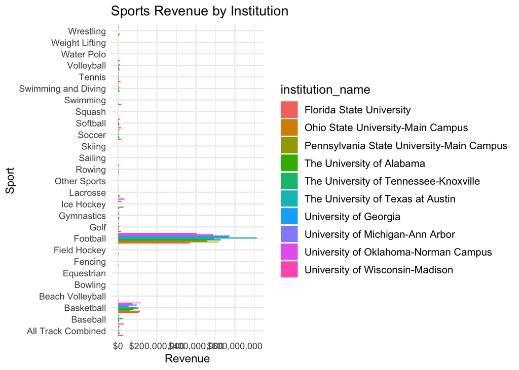

```r
# Let's assume your tibble is stored in a variable named `sports_revenue`
sports_breakdown %>%
  ggplot(aes(x = sports, y = sport_revenue, fill = institution_name)) +
  geom_bar(stat = "identity", position = "dodge") +
  scale_y_continuous(labels = scales::dollar_format(scale = 1)) +  # Format the revenue in dollar format
  coord_flip() +
  labs(title = "Sports Revenue by Institution",
       x = "Sport",
       y = "Revenue") +
  theme_minimal() +
  theme(legend.title = element_text(size = 12),
        legend.text = element_text(size = 10))
```

### Revenue by sports for UT Austin

```r
sports %>%
  select(year, institution_name, partic_men, partic_women, total_rev_menwomen, sports) %>%
  filter(!is.na(total_rev_menwomen) & institution_name == "The University of Texas at Austin" & year == 2019) %>%
  arrange(desc(total_rev_menwomen))
```

```
## # A tibble: 11 × 6
##     year institution_name      partic_men partic_women total_rev_menwomen sports
##    <dbl> <chr>                      <dbl>        <dbl>              <dbl> <chr>
##  1  2019 The University of Te…        120           NA          144426105 Footb…
##  2  2019 The University of Te…         18           29           15209528 Baske…
##  3  2019 The University of Te…         43           NA            2666869 Baseb…
##  4  2019 The University of Te…         NA           14            1446017 Volle…
##  5  2019 The University of Te…         NA           22             818530 Softb…
##  6  2019 The University of Te…        108          107             783607 All T…
##  7  2019 The University of Te…         44           36             762129 Swimm…
##  8  2019 The University of Te…         12            8             683563 Golf
##  9  2019 The University of Te…         NA           29             527414 Soccer
## 10  2019 The University of Te…          9            9             390204 Tennis
## 11  2019 The University of Te…         NA          106             309574 Rowing
```

### What is the total revenue generated from college sports in Texas?

```r
sports %>%
  select(state_cd, total_rev_menwomen) %>%
  group_by(state_cd = "TX") %>%
  summarise(total_rev_menwomen = sum(total_rev_menwomen, na.rm = TRUE))
```

[output not shown]

### Revenue by sports for Indiana University

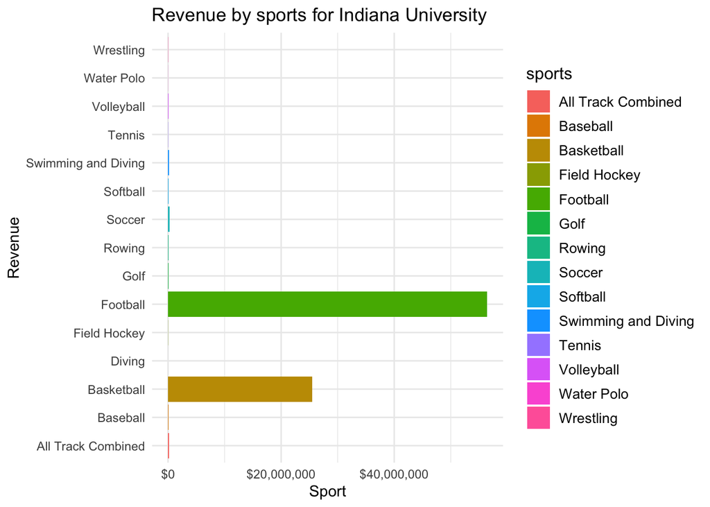

```r
indianaUniversity <- sports %>%
  select(year, institution_name, sports, total_rev_menwomen) %>%
  filter(year == 2019, institution_name == "Indiana University-Bloomington") %>%
  arrange(desc(total_rev_menwomen)) %>%
  head(15) %>%
  ggplot(aes(total_rev_menwomen, sports, fill = sports)) +
  geom_bar(stat = "identity") +
  scale_x_continuous(labels = scales::dollar_format(scale = 1)) +
  labs(title = "Revenue by sports for Indiana University",
       x = "Sport",
       y = "Revenue") +
  theme_minimal() +
  theme(legend.title = element_text(size = 12),
        legend.text = element_text(size = 10))

print(indianaUniversity)
```

### What Sport do women participate in the most in college?

```r
sports %>%
  select(sports, partic_women) %>%
  group_by(sports) %>%
  summarise(total_women = sum(partic_women, na.rm = TRUE)) %>%
  arrange(desc(total_women))
```

```
## # A tibble: 38 × 2
##    sports                     total_women
##    <chr>                            <dbl>
##  1 All Track Combined              297313
##  2 Soccer                          199483
##  3 Softball                        161441
##  4 Basketball                      144036
##  5 Volleyball                      139335
##  6 Lacrosse                         63143
##  7 Tennis                           51894
##  8 Track and Field, Outdoor         46945
##  9 Swimming and Diving              45720
## 10 Track and Field, X-Country       39014
## # ℹ 28 more rows
```

### What is the distribuion between men and womens in different sports in college?

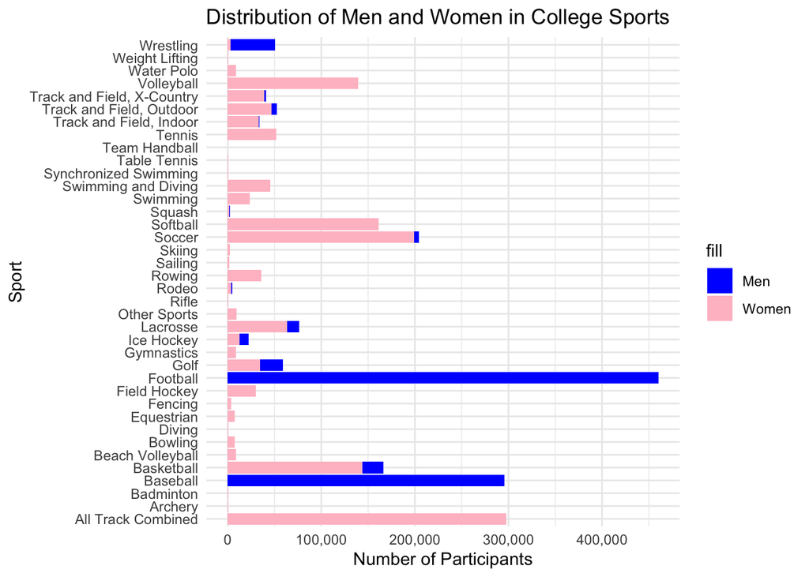

```r
menWomenParicSports <- sports %>%
  select(sports, partic_men, partic_women) %>%
  group_by(sports) %>%
  summarise(
    total_women = sum(partic_women, na.rm = TRUE),
    total_men = sum(partic_men, na.rm = TRUE)
  )

library(scales)

menWomenParicSports %>%
  ggplot(aes(x = sports)) +
  geom_bar(aes(y = total_men, fill = "Men"), stat = "identity") +
  geom_bar(aes(y = total_women, fill = "Women"), stat = "identity", position = "stack") +
  coord_flip() +
  labs(title = "Distribution of Men and Women in College Sports",
       x = "Sport", y = "Number of Participants") +
  theme_minimal() +
  scale_fill_manual(values = c("Men" = "blue", "Women" = "pink")) +
  scale_y_continuous(labels = comma)
```

### What is the revenue distrubtion for different sports by men and women?

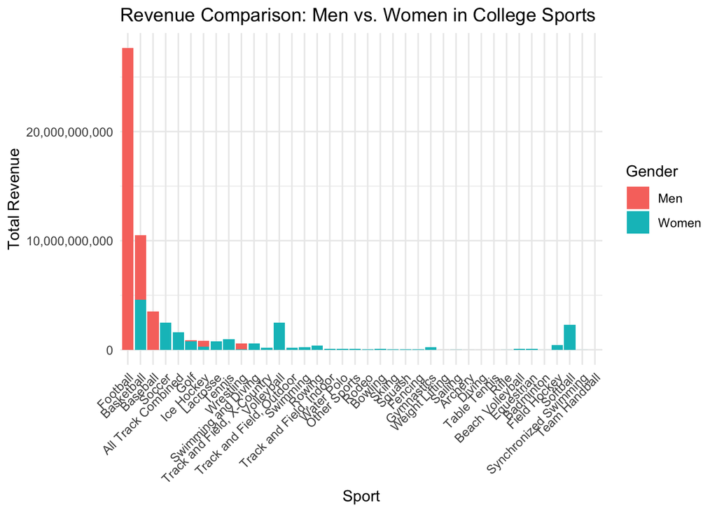

```r
totalRevMen <- sports %>%
  select(sports, rev_men) %>%
  group_by(sports) %>%
  summarise(total_rev_men = sum(rev_men, na.rm = TRUE)) %>%
  arrange(desc(total_rev_men))

totalRevWomen <- sports %>%
  select(sports, rev_women) %>%
  group_by(sports) %>%
  summarise(total_rev_women = sum(rev_women, na.rm = TRUE)) %>%
  arrange(desc(total_rev_women))

combined_data <- left_join(totalRevMen, totalRevWomen, by = "sports")

ggplot(data = combined_data, aes(x = reorder(sports, -total_rev_men))) +   # Ordering bars by total_rev_men
  geom_bar(aes(y = total_rev_men, fill = "Men"), stat = "identity", position = "dodge") +
  geom_bar(aes(y = total_rev_women, fill = "Women"), stat = "identity", position = "dodge") +
  labs(
    title = "Revenue Comparison: Men vs. Women in College Sports",
    y = "Total Revenue",
    x = "Sport",
    fill = "Gender"
  ) +
  theme_minimal() +
  scale_y_continuous(labels = comma) +
  theme(axis.text.x = element_text(angle = 45, hjust = 1))
```

### What universities have the most male and female students?

```r
sports %>%
  select(institution_name, year, ef_female_count, ef_male_count, ef_total_count) %>%
  filter(ef_female_count > 17000 & ef_male_count > 17000 & year == 2019) %>%
  distinct() %>%
  arrange(desc(ef_total_count))
```

```
## # A tibble: 7 × 5
##   institution_name             year ef_female_count ef_male_count ef_total_count
##   <chr>                       <dbl>           <dbl>         <dbl>          <dbl>
## 1 Pennsylvania State Univers…  2019           30325         35954          66279
## 2 Texas A & M University-Col…  2019           22594         24943          47537
## 3 Ohio State University-Main…  2019           20816         21770          42586
## 4 University of Central Flor…  2019           22963         19221          42184
## 5 Arizona State University-T…  2019           18511         22447          40958
## 6 Michigan State University    2019           18114         17461          35575
## 7 Rutgers University-New Bru…  2019           17044         17189          34233
```

### What is the total male count vs women count across UT Austin?

```r
sports %>%
  filter(institution_name == "The University of Texas at Austin") %>%
  distinct(ef_male_count, year)
```

```
## # A tibble: 5 × 2
##   ef_male_count  year
##           <dbl> <dbl>
## 1         17192  2015
## 2         17325  2016
## 3         17419  2017
## 4         17313  2018
## 5         16826  2019
```

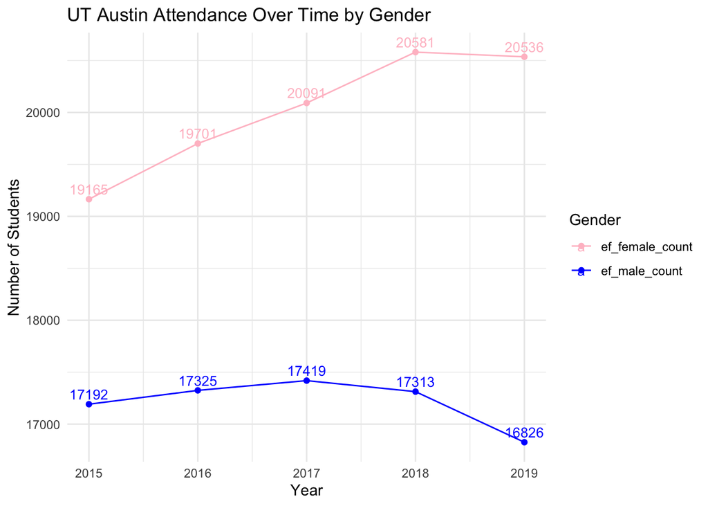

```r
UTAustinEfMaleCount <- sports %>%
   filter(institution_name == "The University of Texas at Austin") %>%
  distinct(ef_male_count, year)

UTAustinEfFemaleCount <- sports %>%
   filter(institution_name == "The University of Texas at Austin") %>%
  distinct(ef_female_count, year)

combinedUTAustinMenWomen <- left_join(UTAustinEfMaleCount, UTAustinEfFemaleCount, by = "year")

library(ggplot2)
library(tidyr)

combinedUTAustinMenWomen %>%
  pivot_longer(cols = c(ef_male_count, ef_female_count),
               names_to = "gender",
               values_to = "count") %>%
  ggplot(aes(x=year, y=count, color=gender, group=gender)) +
  geom_line() +
  geom_point() +
  geom_text(aes(label=count), vjust=-0.5, size=3.5) +  # This line adds labels. You can adjust `vjust` for vertical position and `size` for text size
  labs(title = "UT Austin Attendance Over Time by Gender",
       x = "Year",
       y = "Number of Students",
       color = "Gender") +
  theme_minimal() +
  scale_color_manual(values = c("ef_male_count" = "blue", "ef_female_count" = "pink"))
```

### How has sports revenue changed over time for UT Austin?

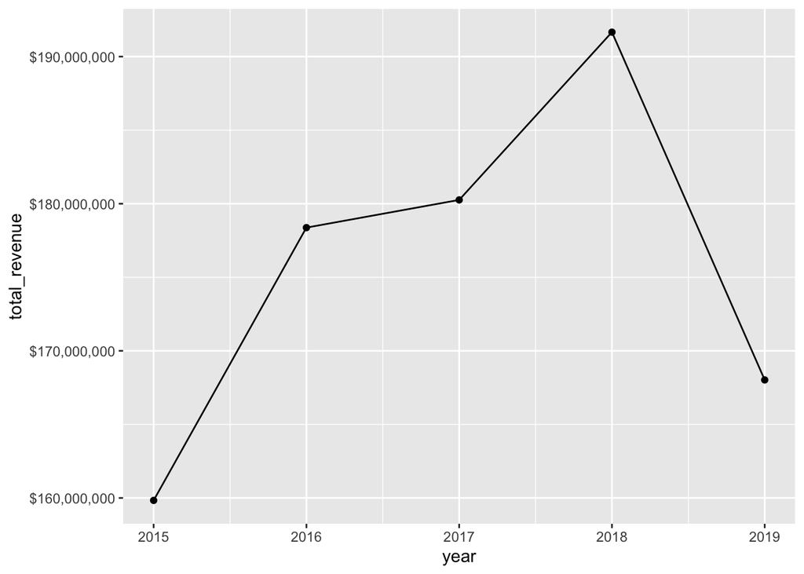

```r
library(scales)
sports %>%
  filter(institution_name == "The University of Texas at Austin") %>%
  group_by(year) %>%
  summarize(total_revenue = sum(total_rev_menwomen, na.rm = TRUE)) %>%
  ggplot(aes(year, total_revenue)) +
  geom_line() +
  geom_point() +
  scale_y_continuous(labels = scales::dollar_format(scale = 1))
```

### What is football revenue overtime for the top 10 universities by total sports revenue?

```r
sports %>%
  group_by(sports, year) %>%
  summarise(total_revenue = sum(total_rev_menwomen, na.rm = TRUE)) %>%
  arrange(desc(total_revenue)) %>%
  head(10)
```

```
## # A tibble: 10 × 3
## # Groups:   sports [2]
##    sports      year total_revenue
##    <chr>      <dbl>         <dbl>
##  1 Football    2019    5912043367
##  2 Football    2018    5848506004
##  3 Football    2017    5645527375
##  4 Football    2016    5271565181
##  5 Football    2015    4979020853
##  6 Basketball  2018    3209597156
##  7 Basketball  2019    3071985770
##  8 Basketball  2017    3066001854
##  9 Basketball  2016    2930311218
## 10 Basketball  2015    2802148944
```

```r
top_schools_year <- sports %>%
  group_by(institution_name) %>%
  summarise(school_total_revenue = sum(total_rev_menwomen, na.rm = TRUE)) %>%
  arrange(desc(school_total_revenue)) %>%
  head(10) %>%
  pull(institution_name)

# List the revenues of sports programs for each of these top 10 schools
sports_breakdown_year <- sports %>%
  filter(institution_name %in% top_schools_year,
         !(sports %in% c("Rifle", "Weight lifting", "Archery", "Synchronized Swimming", "Diving", "Badminton", "Table Tennis", "Team Handball", "Rodeo", "Skiiing", "Track and Field, Indoor", "Track and Field, X-Country", "Track and Field, Outdoor"))) %>%
  group_by(institution_name, sports, year) %>%
  summarise(sport_revenue = sum(total_rev_menwomen, na.rm = TRUE)) %>%
  arrange(institution_name, desc(sport_revenue))
print(sports_breakdown)
```

```
## # A tibble: 244 × 3
## # Groups:   institution_name [10]
##    institution_name         sports             sport_revenue
##    <chr>                    <chr>                      <dbl>
##  1 Florida State University Football               369780591
##  2 Florida State University Basketball             106313458
##  3 Florida State University Baseball                29828148
##  4 Florida State University All Track Combined      24555473
##  5 Florida State University Swimming                15570738
##  6 Florida State University Golf                    13663327
##  7 Florida State University Soccer                  13657050
##  8 Florida State University Softball                13348196
##  9 Florida State University Tennis                  11827272
## 10 Florida State University Volleyball               8889259
## # ℹ 234 more rows
```

```r
sports_breakdown_year %>%
  filter(sports == "Football") %>%
  group_by(year)
```

```
## # A tibble: 50 × 4
## # Groups:   year [5]
##    institution_name                  sports    year sport_revenue
##    <chr>                             <chr>    <dbl>         <dbl>
##  1 Florida State University          Football  2017      87510028
##  2 Florida State University          Football  2016      86565283
##  3 Florida State University          Football  2019      71102595
##  4 Florida State University          Football  2018      68893857
##  5 Florida State University          Football  2015      55708828
##  6 Ohio State University-Main Campus Football  2019     115510031
##  7 Ohio State University-Main Campus Football  2018     115091304
##  8 Ohio State University-Main Campus Football  2017     110661057
##  9 Ohio State University-Main Campus Football  2016      89893135
## 10 Ohio State University-Main Campus Football  2015      86646061
## # ℹ 40 more rows
```

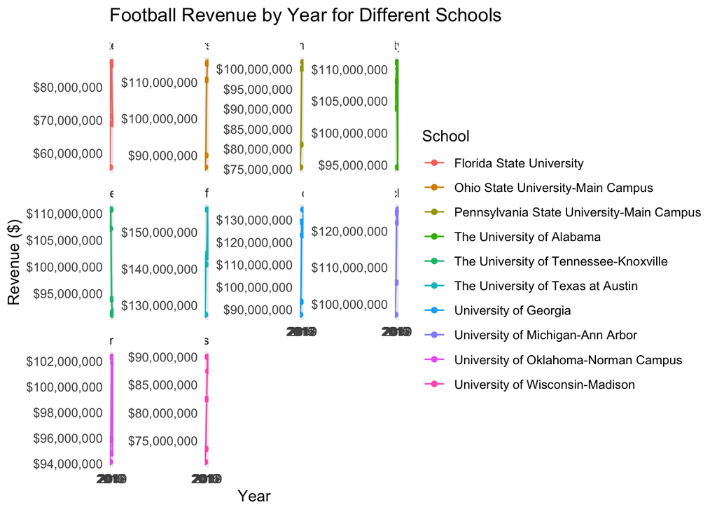

```r
sports_breakdown_year %>%
  filter(sports == "Football") %>%
  ggplot(aes(x=year, y=sport_revenue, color=institution_name)) +
  geom_line(aes(group=institution_name)) +
  geom_point() +
  facet_wrap(~institution_name, scales = "free_y") +
  labs(title="Football Revenue by Year for Different Schools",
       x="Year",
       y="Revenue ($)",
       color="School") +
  scale_y_continuous(labels = scales::dollar_format(label = 1)) +
  theme_minimal()
```

### What states have the schools that generate the highest revenue?

```r
top_states_rev <- sports %>%
  group_by(state_cd) %>%
  summarise(total_revenue = sum(total_rev_menwomen, na.rm = TRUE)) %>%
  arrange(desc(total_revenue))

print(top_states_rev)
```

```
## # A tibble: 54 × 2
##    state_cd total_revenue
##    <chr>            <dbl>
##  1 TX          5154038531
##  2 CA          4519939003
##  3 PA          3316513938
##  4 FL          3196080770
##  5 NC          3072000248
##  6 NY          3041267262
##  7 OH          2485484212
##  8 MI          2281396338
##  9 TN          2191922612
## 10 IN          2167761250
## # ℹ 44 more rows
```

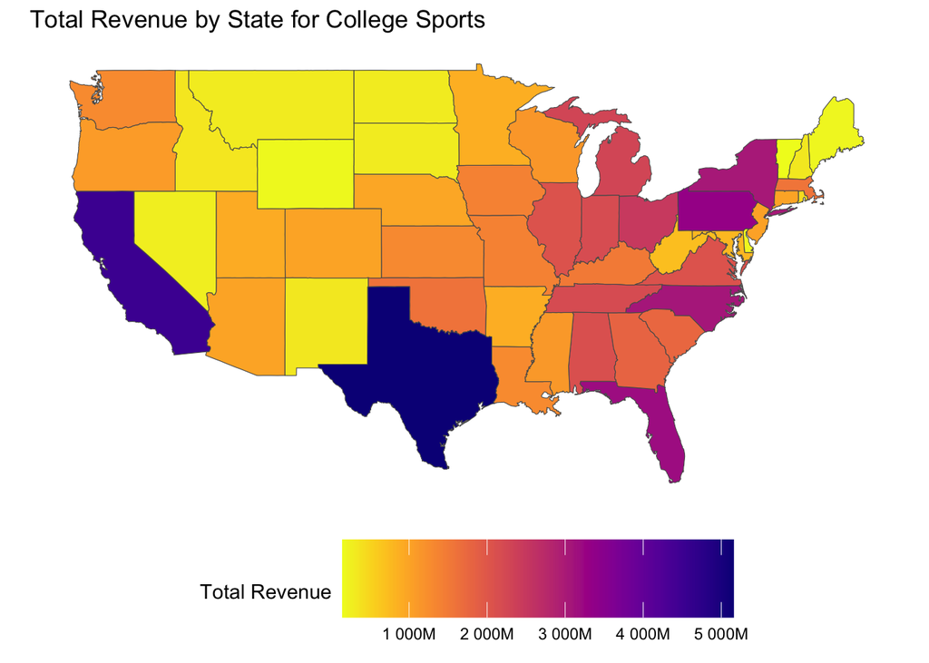

```r
# Install & Load the required packages
options(repos = c(CRAN = "https://cloud.r-project.org/"))
install.packages(c("sf", "viridis"))
library(sf)
library(ggplot2)
library(viridis)
library(maps)
library(scales)

# Add a column of state names to top_states_rev based on abbreviations
top_states_rev$state_name <- state.name[match(top_states_rev$state_cd, state.abb)]

convert_state_code <- function(code) {
  state_lookup <- data.frame(code = state.abb, name = tolower(state.name))
  return(state_lookup$name[state_lookup$code == code])
}

top_states_rev$state_name <- sapply(top_states_rev$state_cd, convert_state_code)

# Get US Map Data
us_states <- maps::map("state", plot = FALSE, fill = TRUE) %>%
  st_as_sf()

top_states_rev$state_name <- as.character(top_states_rev$state_name)

# Merge the map data with your `top_states` data
merged_data <- left_join(us_states, top_states_rev, by = c("ID" = "state_name"))

# Custom function to format numbers into "M" for millions
format_millions <- function(x) {
  return(scales::dollar_format(scale = 1e-6, suffix = "M")(x))
}

breaks_to_use <- scales::pretty_breaks(n = 5)(range(merged_data$total_revenue))

ggplot(data = merged_data) +
  geom_sf(aes(fill = total_revenue)) +
  scale_fill_viridis(name = "Total Revenue", option = "C", direction = -1,
                     labels = scales::label_number(scale = 1e-6, suffix = 'M')) +
  theme_light() +
  labs(title = "Total Revenue by State for College Sports") +
  theme(legend.position = "bottom",
        legend.key.size = unit(1.5, "cm"),
        panel.grid.major = element_blank(),
        panel.grid.minor = element_blank(),
        axis.ticks = element_blank(),
        axis.text = element_blank(),
        panel.border = element_blank())
```

# Inferential Statistics

### Difference in Participation Rates between Genders

```r
t.test(sports$partic_men, sports$partic_women)
```

```
##
##  Welch Two Sample t-test
##
## data:  sports$partic_men and sports$partic_women
## t = 73.419, df = 103622, p-value < 2.2e-16
## alternative hypothesis: true difference in means is not equal to 0
## 95 percent confidence interval:
##   9.882394 10.424504
## sample estimates:
## mean of x mean of y
##  30.86173  20.70828
```

Based on the t-test results, we can conclude that there is a statistically significant difference between the means of participation rates between men and women. Specifically, the mean for partic_men is higher than that for partic_women, with a difference estimated to be between 9.88 and 10.42. This difference is highly significant, given the extremely small p-value.

```r
cor.test(sports$total_exp_menwomen, sports$exp_men)
```

```
##
##  Pearson's product-moment correlation
##
## data:  sports$total_exp_menwomen and sports$exp_men
## t = 1402.3, df = 61863, p-value < 2.2e-16
## alternative hypothesis: true correlation is not equal to 0
## 95 percent confidence interval:
##  0.9843899 0.9848706
## sample estimates:
##       cor
## 0.9846321
```

There’s a very strong positive linear relationship between total_exp_menwomen and exp_men. This means as expenditures for men increase, the total expenditures for both men and women also tend to increase, and vice versa.

The correlation coefficient of approximately 0.9846 is statistically significant with a p-value effectively at 0. This suggests that it’s highly unlikely that such a strong correlation occurred by chance alone.

### Difference in revenue between men and womens sports

```r
t.test(sports$rev_men, sports$rev_women, paired = TRUE)
```

```
##
##  Paired t-test
##
## data:  sports$rev_men and sports$rev_women
## t = 21.653, df = 43613, p-value < 2.2e-16
## alternative hypothesis: true mean difference is not equal to 0
## 95 percent confidence interval:
##  122967.7 147444.9
## sample estimates:
## mean difference
##        135206.3
```

Based on the t-test results, we can say that there’s a statistically significant difference between the revenues of men (rev_men) and women (rev_women) in sports. Specifically, the revenue for men appears to be higher than that for women by an average of approximately $135206.3.

### Association between School Classification and Sports Offered

```r
table_data <- table(sports$classification_name, sports$sports)
chisq.test(table_data)
```

```
##
##  Pearson's Chi-squared test
##
## data:  table_data
## X-squared = 9402.9, df = 666, p-value < 2.2e-16
```

The result indicates that different classifications of schools likely have different distributions of sports offered.